# ANN_Task1_sudoku

Task 1: Digit Recognition in Sudoku **Puzzles**

Importing all the Required library

```python
import torch
import torchvision
import torchvision.transforms as transforms
from torch.utils.data import DataLoader
from torch import nn
```

Creating Datasets and Dataloaders

```python
# MNIST dataset
transform = transforms.Compose([transforms.ToTensor(), transforms.Normalize((0.5,), (0.5,))])
train_dataset = torchvision.datasets.MNIST(root='./data', train=True, download=True, transform=transform)
test_dataset = torchvision.datasets.MNIST(root='./data', train=False, download=True, transform=transform)

# Data loader
train_loader = DataLoader(dataset=train_dataset, batch_size=64, shuffle=True)
test_loader = DataLoader(dataset=test_dataset, batch_size=64, shuffle=False)

print("Dataset reloaded with resized images.")
```

```
Dataset reloaded with resized images.
```

#### Defining the Model

- **Convolutional Layers**: Three convolutional layers (`conv1`, `conv2`, `conv3`) are used to extract spatial features from the input images. Each layer is followed by batch normalization (`bn1`, `bn2`, `bn3`) to stabilize and accelerate training.
- **Activation Function**: Leaky ReLU is used as the activation function after each convolutional layer to introduce non-linearity, allowing for small gradients when the function is not active, which helps with the flow of gradients during backpropagation.
- **Pooling**: Max pooling is applied after each activation to reduce the spatial dimensions of the feature maps, helping to make the detection of features invariant to scale and orientation changes.
- **Dropout**: A dropout layer is included before the final fully connected layer to reduce overfitting by randomly setting a portion of the input units to 0 during training.
- **Fully Connected Layers**: Two linear layers (`fc1`, `fc2`) are used at the end, where `fc1` reduces the dimensionality to 256 features, and `fc2` maps these features to 10 output classes, corresponding to the digits 0-9.

```python
# Neural Network Model
class EnhancedSudokuNet(nn.Module):
    def __init__(self):
        super(EnhancedSudokuNet, self).__init__()
        self.conv1 = nn.Conv2d(1, 32, kernel_size=3, padding=1)
        self.bn1 = nn.BatchNorm2d(32)
        self.conv2 = nn.Conv2d(32, 64, kernel_size=3, padding=1)
        self.bn2 = nn.BatchNorm2d(64)
        self.conv3 = nn.Conv2d(64, 128, kernel_size=3, padding=1)
        self.bn3 = nn.BatchNorm2d(128)
        self.fc1 = nn.Linear(3*3*128, 256)
        self.fc2 = nn.Linear(256, 10)
        self.leaky_relu = nn.LeakyReLU(negative_slope=0.01)
        self.maxpool = nn.MaxPool2d(kernel_size=2, stride=2)
        self.dropout = nn.Dropout(0.5)

    def forward(self, x):
        x = self.maxpool(self.leaky_relu(self.bn1(self.conv1(x))))
        x = self.maxpool(self.leaky_relu(self.bn2(self.conv2(x))))
        x = self.maxpool(self.leaky_relu(self.bn3(self.conv3(x))))
        x = x.view(x.size(0), -1)  # flatten
        x = self.leaky_relu(self.fc1(x))
        x = self.dropout(x)
        x = self.fc2(x)
        return x


model = EnhancedSudokuNet()
```

```python
# Check if GPU is available
device = torch.device("cuda" if torch.cuda.is_available() else "cpu")
model.to(device)

optimizer = optim.Adam(model.parameters(), lr=0.001)
criterion = nn.CrossEntropyLoss()
```

```
EnhancedSudokuNet(
  (conv1): Conv2d(1, 32, kernel_size=(3, 3), stride=(1, 1), padding=(1, 1))
  (bn1): BatchNorm2d(32, eps=1e-05, momentum=0.1, affine=True, track_running_stats=True)
  (conv2): Conv2d(32, 64, kernel_size=(3, 3), stride=(1, 1), padding=(1, 1))
  (bn2): BatchNorm2d(64, eps=1e-05, momentum=0.1, affine=True, track_running_stats=True)
  (conv3): Conv2d(64, 128, kernel_size=(3, 3), stride=(1, 1), padding=(1, 1))
  (bn3): BatchNorm2d(128, eps=1e-05, momentum=0.1, affine=True, track_running_stats=True)
  (fc1): Linear(in_features=1152, out_features=256, bias=True)
  (fc2): Linear(in_features=256, out_features=10, bias=True)
  (leaky_relu): LeakyReLU(negative_slope=0.01)
  (maxpool): MaxPool2d(kernel_size=2, stride=2, padding=0, dilation=1, ceil_mode=False)
  (dropout): Dropout(p=0.5, inplace=False)
)
```

#### Training Loop

- Trains a neural network over defined epochs.
- Computes and logs training loss and accuracy.
- Evaluates model on validation set for loss and accuracy.
- Plots training/validation loss and accuracy trends.

```
Epoch [1/20], Train Loss: 0.0062, Train Accuracy: 99.80%, Val Loss: 0.0286, Val Accuracy: 99.39%
Epoch [2/20], Train Loss: 0.0056, Train Accuracy: 99.81%, Val Loss: 0.0346, Val Accuracy: 99.36%
Epoch [3/20], Train Loss: 0.0045, Train Accuracy: 99.86%, Val Loss: 0.0365, Val Accuracy: 99.31%
Epoch [4/20], Train Loss: 0.0044, Train Accuracy: 99.87%, Val Loss: 0.0305, Val Accuracy: 99.52%
Epoch [5/20], Train Loss: 0.0069, Train Accuracy: 99.80%, Val Loss: 0.0359, Val Accuracy: 99.35%
Epoch [6/20], Train Loss: 0.0042, Train Accuracy: 99.87%, Val Loss: 0.0330, Val Accuracy: 99.39%
Epoch [7/20], Train Loss: 0.0038, Train Accuracy: 99.87%, Val Loss: 0.0323, Val Accuracy: 99.45%
Epoch [8/20], Train Loss: 0.0037, Train Accuracy: 99.88%, Val Loss: 0.0323, Val Accuracy: 99.41%
Epoch [9/20], Train Loss: 0.0045, Train Accuracy: 99.87%, Val Loss: 0.0383, Val Accuracy: 99.43%
Epoch [10/20], Train Loss: 0.0042, Train Accuracy: 99.87%, Val Loss: 0.0396, Val Accuracy: 99.31%
Epoch [11/20], Train Loss: 0.0047, Train Accuracy: 99.86%, Val Loss: 0.0457, Val Accuracy: 99.20%
Epoch [12/20], Train Loss: 0.0043, Train Accuracy: 99.87%, Val Loss: 0.0366, Val Accuracy: 99.34%
Epoch [13/20], Train Loss: 0.0036, Train Accuracy: 99.90%, Val Loss: 0.0336, Val Accuracy: 99.36%
Epoch [14/20], Train Loss: 0.0033, Train Accuracy: 99.90%, Val Loss: 0.0410, Val Accuracy: 99.25%
Epoch [15/20], Train Loss: 0.0054, Train Accuracy: 99.84%, Val Loss: 0.0428, Val Accuracy: 99.37%
Epoch [16/20], Train Loss: 0.0038, Train Accuracy: 99.89%, Val Loss: 0.0320, Val Accuracy: 99.37%
Epoch [17/20], Train Loss: 0.0033, Train Accuracy: 99.91%, Val Loss: 0.0472, Val Accuracy: 99.23%
Epoch [18/20], Train Loss: 0.0036, Train Accuracy: 99.90%, Val Loss: 0.0485, Val Accuracy: 99.35%
Epoch [19/20], Train Loss: 0.0041, Train Accuracy: 99.87%, Val Loss: 0.0444, Val Accuracy: 99.29%
Epoch [20/20], Train Loss: 0.0037, Train Accuracy: 99.89%, Val Loss: 0.0376, Val Accuracy: 99.38%
Training complete.
```

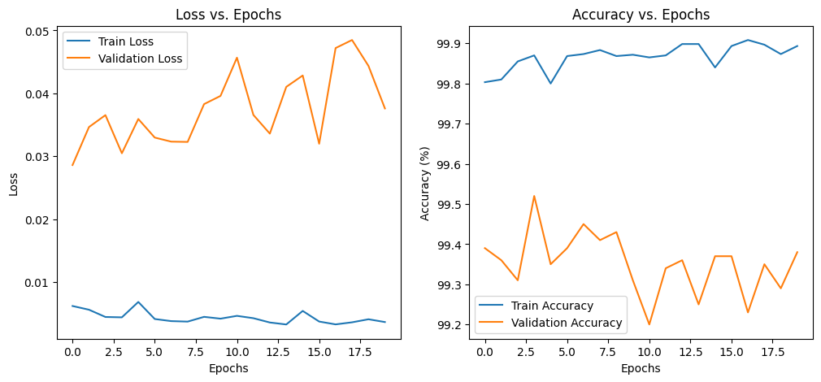

```python
import matplotlib.pyplot as plt

# Initialize lists to monitor training and validation loss and accuracy
train_losses = []
val_losses = []
train_accuracy = []
val_accuracy = []

for epoch in range(num_epochs):
    model.train()
    total_loss = 0
    correct = 0
    total = 0

    for i, (images, labels) in enumerate(train_loader):
        images, labels = images.to(device), labels.to(device)

        # Forward pass
        outputs = model(images)
        loss = criterion(outputs, labels)
        total_loss += loss.item()

        # Backward and optimize
        optimizer.zero_grad()
        loss.backward()
        optimizer.step()

        _, predicted = torch.max(outputs.data, 1)
        total += labels.size(0)
        correct += (predicted == labels).sum().item()

    train_losses.append(total_loss / len(train_loader))
    train_accuracy.append(100 * correct / total)

    # Validation loss
    model.eval()
    val_loss = 0
    correct = 0
    total = 0
    with torch.no_grad():
        for images, labels in test_loader:
            images, labels = images.to(device), labels.to(device)
            outputs = model(images)
            loss = criterion(outputs, labels)
            val_loss += loss.item()
            _, predicted = torch.max(outputs.data, 1)
            total += labels.size(0)
            correct += (predicted == labels).sum().item()

    val_losses.append(val_loss / len(test_loader))
    val_accuracy.append(100 * correct / total)

    print(f'Epoch [{epoch+1}/{num_epochs}], Train Loss: {train_losses[-1]:.4f}, Train Accuracy: {train_accuracy[-1]:.2f}%, Val Loss: {val_losses[-1]:.4f}, Val Accuracy: {val_accuracy[-1]:.2f}%')

print("Training complete.")

# Plotting
plt.figure(figsize=(12, 5))
plt.subplot(1, 2, 1)
plt.plot(train_losses, label='Train Loss')
plt.plot(val_losses, label='Validation Loss')
plt.title('Loss vs. Epochs')
plt.xlabel('Epochs')
plt.ylabel('Loss')
plt.legend()

plt.subplot(1, 2, 2)
plt.plot(train_accuracy, label='Train Accuracy')
plt.plot(val_accuracy, label='Validation Accuracy')
plt.title('Accuracy vs. Epochs')
plt.xlabel('Epochs')
plt.ylabel('Accuracy (%)')
plt.legend()

plt.show()
```

#### Testing the Data

- Loading the test data
- Classifying the digits using trained model

```python
import numpy as np
import torch
from torch.utils.data import Dataset, DataLoader


test_images_path = '/content/drive/MyDrive/Sudoko Dataset Task 1/test/imgs.npy'

# Load test images
test_images = np.load(test_images_path)

# Define a custom dataset for the Sudoku test images
class SudokuDataset(Dataset):
    def __init__(self, images):
        self.images = images

    def __len__(self):
        return len(self.images)

    def __getitem__(self, idx):
        return self.images[idx]

# Create a dataset and data loader for the test images
sudoku_dataset = SudokuDataset(test_images)
sudoku_loader = DataLoader(sudoku_dataset, batch_size=1, shuffle=False)

# Function to access a specific cell
def get_cell(matrix, i, j, cell_size=28):
    start_row = i * cell_size
    start_col = j * cell_size
    return matrix[start_row:start_row+cell_size, start_col:start_col+cell_size]

# Function to combine coordinates with predictions
def combine_coordinates(coordinates, predictions):
    for i in range(len(coordinates)):
        coordinates[i].append(predictions[i])
    return coordinates

# Function to predict with PyTorch model
def predict_with_pytorch_model(image_matrix):
    coordinate_array = []
    array = []

    for i in range(9):
        for j in range(9):
            cell_matrix = get_cell(image_matrix, i, j)
            cell_matrix = torch.tensor(cell_matrix / 255.0, dtype=torch.float32).unsqueeze(0).unsqueeze(0)
            cell_matrix = cell_matrix.to(device)

            if torch.all(cell_matrix == 0):
                pass
            else:
                with torch.no_grad():
                    output = model(cell_matrix)
                    _, predicted = torch.max(output.data, 1)
                    array.append(predicted.item())
                    coordinate_array.append([i, j])

    return combine_coordinates(coordinate_array, array)

predicted_pytorch = []
for image_matrix in sudoku_loader:
    image_matrix = image_matrix.squeeze(0).numpy()  # Convert from tensor to numpy array
    combined = predict_with_pytorch_model(image_matrix)
    predicted_pytorch.append(combined)
```

Visualisation of sub-image

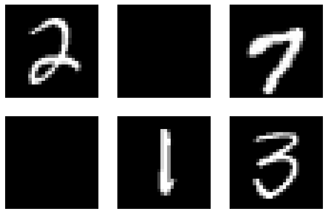

```python
def get_one_cell(image):
    matrix_size = 28
    sliced_img = []

    for i in range(9):  # 9 rows
        for j in range(9):  # 9 columns
            cell = image[i * matrix_size:(i + 1) * matrix_size, j * matrix_size:(j + 1) * matrix_size]
            sliced_img.append(cell)

    return sliced_img

test_cells = get_one_cell(test_images[0])

# Display the first few cells to verify
plt.figure(figsize=(8,8))
for i in range(6):
    plt.subplot(3, 3, i+1)
    plt.imshow(test_cells[i], cmap='gray')
    plt.axis('off')
plt.show()
```

#### Output

- Modifying the Predicted Digits into required format and saving it as csv file

```python
import pandas as pd

def create_submission_file(predicted_sudokus, filename="Task1_sudoku_submission.csv"):
    submission_data = []

    for img_id, sudoku in enumerate(predicted_sudokus):
        # Create a 9x9 grid initialized with 0s (for empty cells)
        grid = [[0 for _ in range(9)] for _ in range(9)]

        # Update the grid with the predicted values
        for cell in sudoku:
            row, col, value = cell
            grid[row][col] = value

        # Format the grid for submission
        for row in range(9):
            for col in range(9):
                cell_id = f"{img_id}_{row}{col}"
                cell_value = grid[row][col]
                submission_data.append([cell_id, cell_value])

    # Create a DataFrame and save it as a CSV file
    submission_df = pd.DataFrame(submission_data, columns=["id", "value"])
    submission_df.to_csv(filename, index=False)
    print(f"Submission file '{filename}' created successfully.")


create_submission_file(predicted_pytorch)
```

```
Submission file 'Task1_sudoku_submission.csv' created successfully.
```